# My Kindle Activity

### Preamble

I find Kindle Insights not as insightful as I wanted them to be, so I requested my Kindle data and dug into some of my reading habits by myself. This analysis uses data from the ReadingSession file (with some personal data removed).

```r
library("tidyverse")
library("lubridate")

library("paletteer")

# For the failed webscrapping part
#library('rvest')
```

```r
read_session <- read.csv("./data/Kindle.Devices.ReadingSession_mod.csv") %>%
  filter(ASIN != "")
```

I soon found out the logs do not include the name of the books, but they refer to an ASIN, which is a code for Amazon products. Well, I could identify to which product they corresponded by using the website. It should be easy to retrieve this information.

It should. But I naively forgot that this would likely not be allowed so here I am with a chunk of code I do not recommend you to run or Amazon will flag you and block you from running automated searches.

```r
# asins <- data.frame(ASIN=unique(read_session$ASIN),
#                     title=NA)
#
# for (asin_it in 1:nrow(asins)){
#
#   asin <- asins[asin_it, "ASIN"]
#   page_url <- paste0('https://www.amazon.com/gp/product/', asin)
#   possibleError <- tryCatch(
#     webpage <- read_html(page_url),
#     error=function(e) e
#   )
#
#   print(possibleError)
#
#   if(!inherits(possibleError, "error")){
#
#     webpage <- read_html(page_url)
#
#     webpage_ <- webpage %>%
#       html_node("div") %>%
#       html_nodes("meta") %>%
#       html_attrs() %>%
#       do.call(c, .)
#
#     title <- webpage_[grep("title", webpage_) + 1]
#     names(title) <- NULL
#
#     if (!is.null(title)){
#       asins$title[asin_it] <- title
#     }
#
#     print(title)
#
#   }
#
# }
#
# list_str <- "Amazon.com|Amazon.com: |Kindle edition.+|: Kindle Store| eBook :.+"
# list_str2 <- " .Portuguese Edition.| .French Edition.| .Spanish Edition."
#
# asins_ <- asins %>%
#   mutate(title = gsub(list_str, "", title)) %>%
#   mutate(title = gsub(list_str2, "", title)) %>%
#   mutate(title = gsub(" - $", "", title))
```

After briefly succeeding, i. e., the code worked for a few IDs and stopped, I realized I would not be able to pursue this path. So I decided to do gather the names manually. I did not read that many books after all.

```r
# asins <- data.frame(ASIN = unique(read_session$ASIN)) %>%
#   mutate(path_book = paste0('https://www.amazon.com/gp/product/', ASIN))
#
# write.csv(asins, file="./data/asins.csv", row.names = FALSE)
```

This version includes the names that I manually retrieved from the website.

```r
asins_ <- read.csv("./data/asins_mod.csv")

read_session_ <- read_session %>%
  left_join(asins_) %>%
  select(-contains("marketplace"), -contains("content"), -path_book)
```

```r
head(read_session_)
```

```
##        start_timestamp        end_timestamp       ASIN total_reading_millis
## 1 2018-01-20T16:47:58Z 2018-01-20T16:50:52Z B01B173GA6               173700
## 2 2018-01-22T01:43:28Z 2018-01-22T02:10:26Z B00BWJC5F6              1618100
## 3 2017-12-29T01:06:06Z 2017-12-29T01:11:47Z B00849BWNS               340500
## 4 2017-12-30T02:14:13Z 2017-12-30T02:14:17Z B00849BWNS                 3100
## 5 2018-01-20T04:15:37Z 2018-01-20T04:20:23Z B01B173GA6               286100
## 6 2018-01-07T01:35:22Z 2018-01-07T01:38:13Z B00849BWNS               171100
##   number_of_page_flips               title
## 1                    1 Pride and Prejudice
## 2                   61  The Princess Bride
## 3                   20     Utilitarianism
## 4                    1     Utilitarianism
## 5                    9 Pride and Prejudice
## 6                    6     Utilitarianism
```

### For how long has Frodo kept me company?

As I was anxious because of my PhD project, I often went back to my comfort books, which were mainly The Lord of the Rings, after I bought it, and Pride and Prejudice, before that.

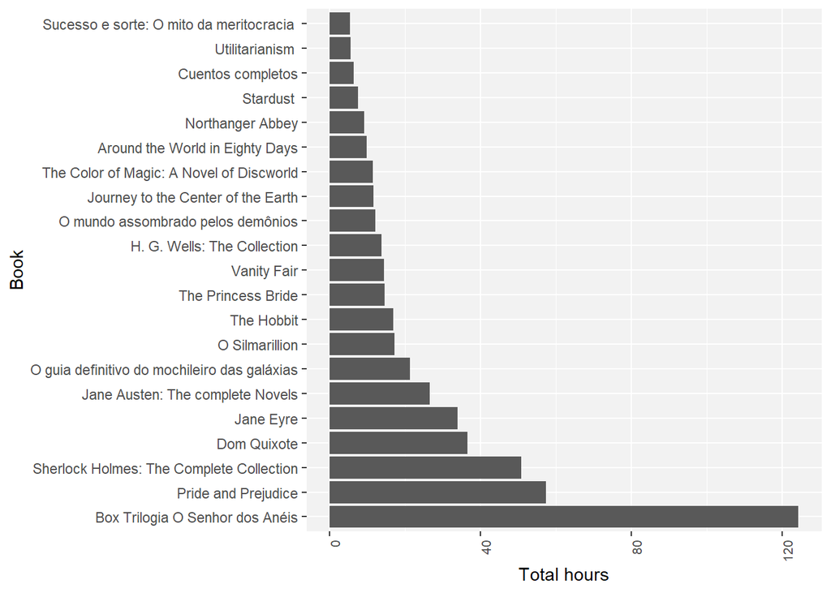

```r
read_session_sum <- read_session_ %>%
  group_by(title, ASIN) %>%
  summarise(tot_hours = sum(total_reading_millis, na.rm = TRUE) / (1000 * 3600)) %>%
  ungroup() %>%
  arrange(desc(tot_hours)) %>%
  filter(tot_hours > 5) %>%
  mutate(title2 = factor(title,
                         levels = title,
                         labels = title,
                         ordered = TRUE))

ggplot(read_session_sum) +
  geom_col(aes(y=title2, x=tot_hours)) +
  labs(x = "Total hours", y = "Book") +
  theme(legend.position = "bottom",
        panel.background = element_rect(fill = "gray95"),
        axis.text.x = element_text(angle = 90,
                                   hjust = 1,
                                   size = 8),
        legend.text = element_text(size = 8))
```

### When was I reading what?

I was also curious regarding at what moment in recent years I was reading, well, LotR, but also the other books from my top 15. The plot also pointed to how often daily reading didn’t sum up to more than one hour.

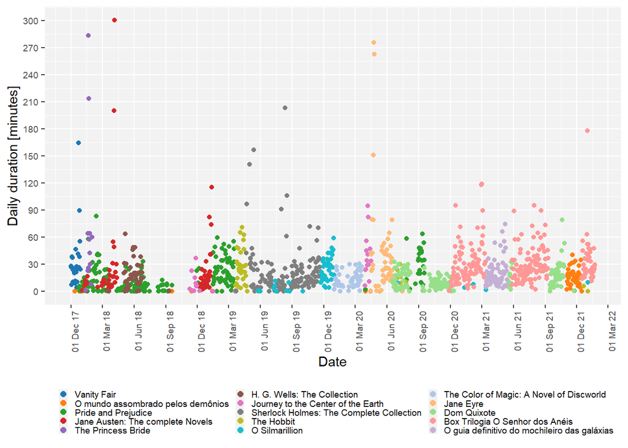

```r
topbooks <- read_session_sum[1:15, "title"]

appear_order <- read_session_ %>%
  mutate(total_reading_millis = total_reading_millis / (1000 * 60),
         start_timestamp = gsub("Z", "", start_timestamp),
         start_timestamp = ymd_hms(start_timestamp)) %>%
  group_by(title) %>%
  summarise(date_ = min(start_timestamp, na.rm = TRUE)) %>%
  ungroup() %>%
  arrange(date_) %>%
  mutate(order_ = row_number()) %>%
  select(-date_)

read_session_all <- read_session_ %>%
  select(start_timestamp, ASIN, total_reading_millis, title) %>%
  filter(title %in% unlist(topbooks)) %>%
  mutate(total_reading_millis = total_reading_millis / (1000 * 60),
         start_timestamp = gsub("Z", "", start_timestamp),
         start_timestamp = ymd_hms(start_timestamp),
         date_ = date(start_timestamp)) %>%
  group_by(date_, title) %>%
  summarise(total_time = sum(total_reading_millis)) %>%
  ungroup() %>%
  left_join(appear_order) %>%
  arrange(order_) %>%
  mutate(title2 = factor(title,
                         levels = title,
                         labels = title,
                         ordered = TRUE))

ggplot(read_session_all) +
  geom_point(aes(x=date_, y=total_time,
                 col=title2),
             position="jitter") +
  labs(x = "Date", y = "Daily duration [minutes]", color="") +
  scale_discrete_manual(values = paletteer_d("ggsci::category20_d3"),
                        aesthetics = "colour") +
  scale_y_continuous(breaks=seq(0, 320 , 30)) +
  scale_x_date(date_breaks = "3 months",
               date_labels = "%d %b %y") +
  guides(colour=guide_legend(override.aes = list(size = 2),
                             ncol = 3, keyheight = 0.5, keywidth = 0.5)) +
  theme(legend.position = "bottom",
        panel.background = element_rect(fill = "gray95"),
        axis.text.x = element_text(angle = 90,
                                   hjust = 1,
                                   size = 7),
        axis.text.y = element_text(size = 7),
        legend.text = element_text(size = 7))
```

### Time to go to bed

And at which hour in the day I read more often. This one is interesting because I have the habit of reading before going to bed. But it also happens that some insomnia may hit and I end up by picking up my Kindle to take my mind out of whatever is preventing my sleep.

There are some clear issues regarding Daylight Saving Time, indicated by sudden shifts in the hour in which I started reading, usually by October and February. These are likely related to DST no longer being applied in Brazil and this being ignored in the conversion I made. I’ve fought this battle once, I don’t want to try to fix it again.

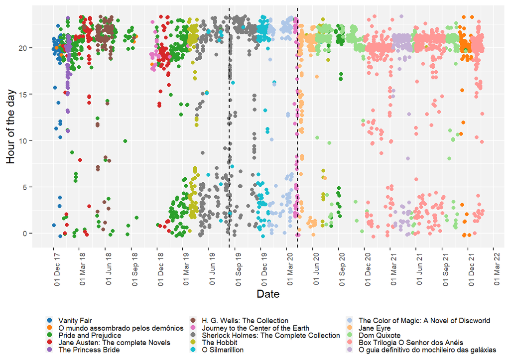

```r
read_session_all <- read_session_ %>%
  select(start_timestamp, ASIN, total_reading_millis, title) %>%
  filter(title %in% unlist(topbooks)) %>%
  mutate(total_reading_millis = total_reading_millis / (1000 * 60),
         start_timestamp = gsub("Z", "", start_timestamp),
         start_timestamp = ymd_hms(start_timestamp),
         date_ = date(start_timestamp),
         start_timestamp_ = if_else((date_ >= as.Date("2019-08-12")) &
                                      (date_ <= as.Date("2020-04-09")),
                                       with_tz(start_timestamp, "US/Eastern"),
                                       with_tz(start_timestamp, "Etc/GMT-3")),
         hour_ = hour(start_timestamp_)) %>%
  left_join(appear_order) %>%
  arrange(order_) %>%
  mutate(title2 = factor(title,
                         levels = title,
                         labels = title,
                         ordered = TRUE))

ggplot(read_session_all) +
  geom_point(aes(x=date_, y=hour_,
                 col=title2),
             position="jitter") +
  geom_vline(aes(xintercept=as.Date("2019-08-12")), lty = 2) +
  geom_vline(aes(xintercept=as.Date("2020-04-09")), lty = 2) +
  labs(x = "Date", y = "Hour of the day", color="") +
  scale_discrete_manual(values = paletteer_d("ggsci::category20_d3"),
                        aesthetics = "colour") +
  scale_alpha_continuous(name="Duration",
                         breaks=c(0, 30),
                         labels=c(0, 30)) +
  scale_x_date(date_breaks = "3 months",
               date_labels = "%d %b %y") +
  guides(colour=guide_legend(override.aes = list(size = 2),
                             ncol = 3, keyheight = 0.5, keywidth = 0.5)) +
  theme(legend.position = "bottom",
        panel.background = element_rect(fill = "gray95"),
        axis.text.x = element_text(angle = 90,
                                   hjust = 1,
                                   size = 7),
        axis.text.y = element_text(size = 7),
        legend.text = element_text(size = 7))
```